# Treatment effect of 6x R-CHOP21+2R versus 6x R-CHOP21 of patients with DLBCL diagnosed between 2014 and 2018

Carolien C.H.M. Maas

July 2023

# Load packages

```r
# remove previous history
rm(list = ls(all.names=TRUE))

# Load packages
library(haven)       # import STATA file
library(lubridate)   # adding weeks to dates
library(mice)        # imputation
library(dplyr)
library(rms)         # rcs
library(survival)    # Kaplan-Meier curve
library(survminer)   # plot Kaplan-Meier
library(openxlsx)    # write to Excel
library(ggplot2)     # plots
library(RISCA)       # ipw.log.rank
library(ggpubr)      # plots patient characteristics
library(patchwork)   # combine plots
seed <- 100
set.seed(seed)
```

# Load data

```r
DLBCL.orig <- haven::read_dta(paste0(file.path, "Data/analyses_1007.dta"))
DLBCL.orig <- DLBCL.orig[!is.na(DLBCL.orig$txstart_rchop21),]
cat("Number of included patients:", nrow(DLBCL.orig), "\n")
```

```
## Number of included patients: 1714
```

##### Exclusion of patients

```r
cat(" Missing stop date :" , sum(is.na(DLBCL.orig$txstop_rit)), "\n",
    "Missing start date:", sum(is.na(DLBCL.orig$txstart_rchop21)), "\n")
```

[output not shown]

```r
DLBCL.raw <- DLBCL.orig[!is.na(DLBCL.orig$txstop_rit),]
```

```
In total, 1691 patients are included of which received
 6x R-CHOP21: 757
 6x R-CHOP21+1R: 41
 6x R-CHOP21+2R: 893
```

##### Recode

Make gender binary 0/1

```r
DLBCL.raw$geslacht <- DLBCL.raw$geslacht-1
```

If `center` is missing, define that this patient was not treated in an academic center.

```r
DLBCL.raw$center[is.na(DLBCL.raw$center)] <- 0
```

Define time at which patients are at risk, which is the end of the possible 8th cycle (second additional rituximab treatment).

```r
# at risk at start of 6th/7th/8th cycle
DLBCL.raw$at.risk <- as.Date(DLBCL.raw$txstop_rit)

# add 63 days for 6x R-CHOP21    (RCHOP21==0)
# add 42 days for 6x R-CHOP21+1R (RCHOP21==9)
# add 21 days for 6x R-CHOP21+2R (RCHOP21==1) because txstop_rit is almost at the start of the cycle
DLBCL.raw <- DLBCL.raw |>
  mutate(
    at.risk = case_when(
      RCHOP21==0 ~ txstop_rit + lubridate::days(63),
      RCHOP21==9 ~ txstop_rit + lubridate::days(42),
      RCHOP21==1 ~ txstop_rit + lubridate::days(21)
  ))
```

```r
DLBCL.raw$EFS.time <- as.numeric(difftime(DLBCL.raw$efsdat, DLBCL.raw$at.risk, unit="weeks"))/52
DLBCL.raw$OS.time <- as.numeric(difftime(DLBCL.raw$osdat, DLBCL.raw$at.risk, unit="weeks"))/52
cat("Number of patients with death before date at risk:", sum(DLBCL.raw$OS.time<0), "\n",
    "Number of patients treated with 6x R-CHOP21 with death before date at risk:", sum(DLBCL.raw$OS.time<0&DLBCL.raw$RCHOP21==0), "\n",
    "Number of patients treated with 6x R-CHOP21 + 1R with death before date at risk:", sum(DLBCL.raw$OS.time<0&DLBCL.raw$RCHOP21==9), "\n",
    "Number of patients treated with 6x R-CHOP21 + 2R with death before date at risk:", sum(DLBCL.raw$OS.time<0&DLBCL.raw$RCHOP21==1), "\n",
    "Number of patients with event before date at risk:", sum(DLBCL.raw$EFS.time<0), "\n",
    "Number of patients treated with 6x R-CHOP21 with event before date at risk:", sum(DLBCL.raw$EFS.time<0&DLBCL.raw$RCHOP21==0), "\n",
    "Number of patients treated with 6x R-CHOP21 + 1R with event before date at risk:", sum(DLBCL.raw$EFS.time<0&DLBCL.raw$RCHOP21==9), "\n",
    "Number of patients treated with 6x R-CHOP21 + 2R with event before date at risk:", sum(DLBCL.raw$EFS.time<0&DLBCL.raw$RCHOP21==1), "\n")
```

```
## Number of patients with death before date at risk: 46
##  Number of patients treated with 6x R-CHOP21 with death before date at risk: 37
##  Number of patients treated with 6x R-CHOP21 + 1R with death before date at risk: 7
##  Number of patients treated with 6x R-CHOP21 + 2R with death before date at risk: 2
##  Number of patients with event before date at risk: 114
##  Number of patients treated with 6x R-CHOP21 with event before date at risk: 85
##  Number of patients treated with 6x R-CHOP21 + 1R with event before date at risk: 11
##  Number of patients treated with 6x R-CHOP21 + 2R with event before date at risk: 18
```

```r
# OMIT patients with death before stop date
DLBCL.raw <- DLBCL.raw[-which(DLBCL.raw$OS.time<0),]

# add 6x R-CHOP21 + 1R to the 6x R-CHOP21 + 2R group
table(DLBCL.raw$RCHOP21)
```

```
##
##   0   1   9
## 720 891  34
```

```r
DLBCL.raw$RCHOP21[DLBCL.raw$RCHOP21==9] <- 1

cat("Number of patients treated with 6x RCHOP21 with event in first 30 days:", sum(DLBCL.raw$EFS.time<30/365&DLBCL.raw$RCHOP21==0), "\n",
    "Number of patients treated wiht 6x RCHOP21 with death in first 30 days:", sum(DLBCL.raw$OS.time<30/365&DLBCL.raw$RCHOP21==0), "\n")
```

```
## Number of patients treated with 6x RCHOP21 with event in first 30 days: 64
##  Number of patients treated wiht 6x RCHOP21 with death in first 30 days: 14
```

Make all variables numeric.

```r
DLBCL.raw <- as.data.frame(lapply(DLBCL.raw, as.numeric, na.rm=FALSE))
```

Ensure categorical variables are considered as factors, such that dummies are created for each level in regression.

```r
DLBCL.raw$sescat <- as.factor(DLBCL.raw$sescat)
DLBCL.raw$stadium <- as.factor(DLBCL.raw$stadium)
DLBCL.raw$region <- as.factor(DLBCL.raw$region)
```

#### Check stage for those with missing performance status

```r
# many patients with missing performance status were in stage 4,
# thus imputation is needed even though 42% is missing
table(DLBCL.raw[is.na(DLBCL.raw$ipi_ps), "stadium"])
```

```
##
##   2   3   4
## 191 174 339
```

### Describe data

```r
to.be.imputed.DLBCL <- DLBCL.raw[, c("RCHOP21", "geslacht", "lft", "stadium",
    "ipi_ldh", "ipi_extra", "ipi_score", "ipi_ps", "region",
    "sescat", "malignancy", "center", "efsi", "EFS.time", "dood", "OS.time",
    "jaar", "respons")]
```

### Impute missing data with multiple imputation

```r
# exclude respons from data frame before starting multiple imputation
to.be.imputed.DLBCL <- to.be.imputed.DLBCL %>% select(-respons)
m <- 50
DLBCL <- mice::mice(to.be.imputed.DLBCL, m=m, print=FALSE, seed=seed)
```

##### Define IPI score

```r
# create long format
# include = logical to indicate whether the original data with the missing values should be included
DLBCL_long <- mice::complete(DLBCL, action="long", include=T)

# calculate IPI score after imputation
DLBCL_long$ipi_score <- as.numeric(DLBCL_long$lft>60) + DLBCL_long$ipi_ldh + DLBCL_long$ipi_ps +
  as.numeric(DLBCL_long$stadium!=2) + DLBCL_long$ipi_extra
DLBCL_long$ipi_score[DLBCL_long$ipi_score==0] <- 1
DLBCL_long$ipi_score[DLBCL_long$ipi_score==5] <- 4
```

Define some variables binary instead of categorical after imputation

```r
DLBCL_long$stage2 <- as.numeric(DLBCL_long$stadium==2)
DLBCL_long$stage3 <- as.numeric(DLBCL_long$stadium==3)
DLBCL_long$stage4 <- as.numeric(DLBCL_long$stadium==4)
for (regio in 1:9){
  DLBCL_long[, paste0("region", regio)] <- as.numeric(DLBCL_long$region==regio)
}
DLBCL_long$ses.low <- as.numeric(DLBCL_long$sescat==0)
DLBCL_long$ses.medium <- as.numeric(DLBCL_long$sescat==1)
DLBCL_long$ses.high <- as.numeric(DLBCL_long$sescat==2)

# revert back to MICE object
DLBCL <- as.mids(DLBCL_long)
```

Save the distributions of all variables, which is necessary for Harrell summaries.

```r
single.imp.DLBCL <- mice::complete(DLBCL, m)
dd <- rms::datadist(single.imp.DLBCL)
options(datadist="dd")
```

# Propensity score model

1. RCHOP21 indicates whether the patient received 6x R-CHOP21 or 6x R-CHOP21+2R.
2. region indicates the region where the patient is treated.
3. The International Prognostic Index (IPI) consists of
- an indicator of age > 60 (lft)
- stage 3 or 4 (stadium)
- elevated serum LDH (ipi_ldh)
- WHO score ECOG/Zubrod status 2, 3, or 4 (ipi_ps)
- more than 1 extranodal site (ipi_extra).
4. malignancy indicates if a patient had one or more previous malignancy
5. center indicates if the center that the patient is treated in was academic or not
6. ses indicates Social Economic Status, which is a proxy for comorbidity, and is divided into low, medium, and high.

```r
# fixed effects propensity score model
PS.formula <- RCHOP21~geslacht+lft+stadium+ipi_ldh+ipi_ps+ipi_extra+malignancy+region+center+ses.low+ses.high
PS.model <- fit.mult.impute(PS.formula, lrm,
                            xtrans=DLBCL,
                            data=to.be.imputed.DLBCL,
                            n.impute=m, pr=FALSE, fit.reps=TRUE,
                            y=TRUE, x=TRUE, se.fit=TRUE)
summary(PS.model)
```

```
##              Effects              Response : RCHOP21
##
##  Factor        Low High Diff. Effect    S.E.     Lower 0.95 Upper 0.95
##  geslacht       0   1    1     0.129090 0.112660 -0.091725   0.349900
##   Odds Ratio    0   1    1     1.137800       NA  0.912360   1.418900
##  lft           63  77   14     0.151670 0.070713  0.013074   0.290260
##   Odds Ratio   63  77   14     1.163800       NA  1.013200   1.336800
##  ipi_ldh        0   1    1     0.152680 0.119550 -0.081631   0.386980
##   Odds Ratio    0   1    1     1.164900       NA  0.921610   1.472500
##  ipi_ps         0   1    1    -0.111670 0.194300 -0.492500   0.269160
##   Odds Ratio    0   1    1     0.894340       NA  0.611100   1.308900
##  ipi_extra      0   1    1     0.046038 0.165950 -0.279230   0.371300
##   Odds Ratio    0   1    1     1.047100       NA  0.756370   1.449600
##  malignancy     0   1    1     0.069990 0.169670 -0.262560   0.402540
##   Odds Ratio    0   1    1     1.072500       NA  0.769080   1.495600
##  center         0   1    1    -0.302770 0.179310 -0.654220   0.048680
##   Odds Ratio    0   1    1     0.738770       NA  0.519850   1.049900
##  ses.low        0   1    1     0.087713 0.139070 -0.184860   0.360290
##   Odds Ratio    0   1    1     1.091700       NA  0.831220   1.433700
##  ses.high       0   1    1    -0.026553 0.136760 -0.294590   0.241480
##   Odds Ratio    0   1    1     0.973800       NA  0.744840   1.273100
##  stadium - 2:4  3   1   NA    -0.489290 0.171650 -0.825710  -0.152870
##   Odds Ratio    3   1   NA     0.613060       NA  0.437920   0.858240
##  stadium - 3:4  3   2   NA    -0.073423 0.171300 -0.409170   0.262320
##   Odds Ratio    3   2   NA     0.929210       NA  0.664200   1.299900
##  region - 1:6   6   1   NA    -0.224430 0.217020 -0.649790   0.200920
##   Odds Ratio    6   1   NA     0.798970       NA  0.522150   1.222500
##  region - 2:6   6   2   NA     0.315430 0.380520 -0.430370   1.061200
##   Odds Ratio    6   2   NA     1.370900       NA  0.650270   2.889900
##  region - 3:6   6   3   NA     0.255690 0.222200 -0.179800   0.691190
##   Odds Ratio    6   3   NA     1.291400       NA  0.835430   1.996100
##  region - 4:6   6   4   NA     1.493100 0.245020  1.012800   1.973300
##   Odds Ratio    6   4   NA     4.450700       NA  2.753400   7.194400
##  region - 5:6   6   5   NA    -0.460130 0.215530 -0.882570  -0.037692
##   Odds Ratio    6   5   NA     0.631200       NA  0.413720   0.963010
##  region - 7:6   6   7   NA    -1.936400 0.194110 -2.316800  -1.555900
##   Odds Ratio    6   7   NA     0.144220       NA  0.098585   0.210990
##  region - 8:6   6   8   NA    -0.417200 0.184830 -0.779460  -0.054937
##   Odds Ratio    6   8   NA     0.658890       NA  0.458650   0.946540
##  region - 9:6   6   9   NA    -1.416400 0.226090 -1.859500  -0.973220
##   Odds Ratio    6   9   NA     0.242600       NA  0.155750   0.377860
```

The propensity score ($e_i$), i.e. the predicted probability of treatment, averaged over multiple imputations.

```r
comb.pred.imp <- c()
for (imp in 1:m){
  comb.pred.imp <- cbind(comb.pred.imp, plogis(predict(PS.model, type="lp", newdata=mice::complete(DLBCL, imp))))
}
single.imp.DLBCL$e.i <- rowMeans(comb.pred.imp)
```

Assess the performance of the propensity score model.

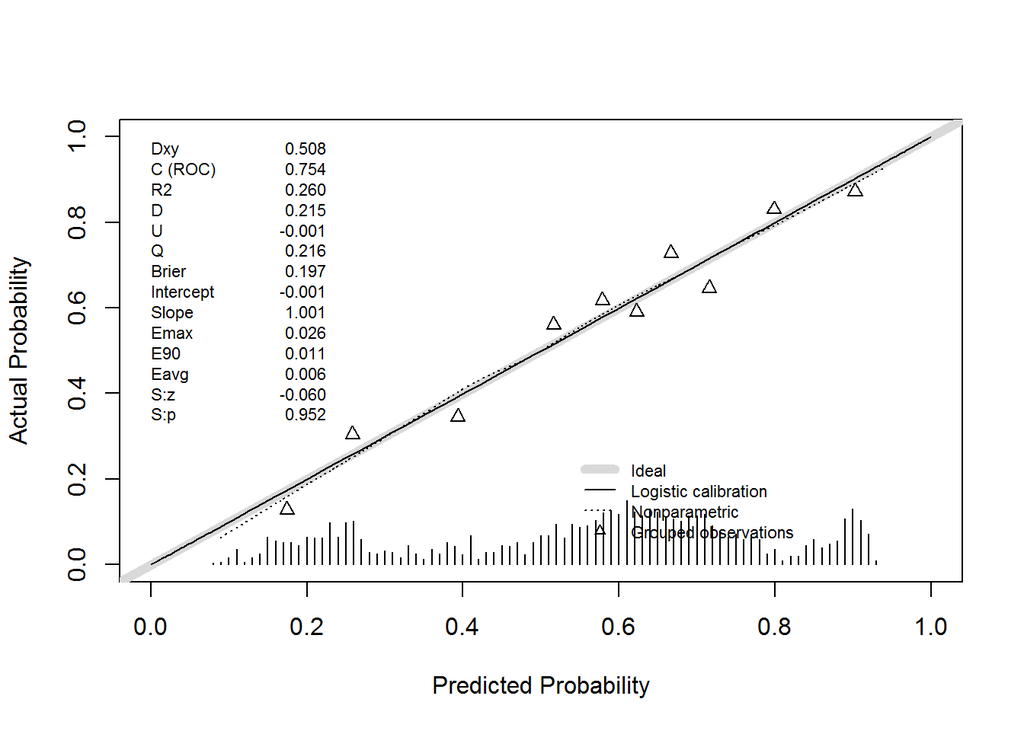

```
##           Dxy       C (ROC)            R2             D      D:Chi-sq
##  5.080631e-01  7.540315e-01  2.596680e-01  2.147315e-01  3.542333e+02
##           D:p             U      U:Chi-sq           U:p             Q
##            NA -1.215494e-03  5.120275e-04  9.997440e-01  2.159470e-01
##         Brier     Intercept         Slope          Emax           E90
##  1.968269e-01 -1.162875e-03  1.000891e+00  2.598145e-02  1.147777e-02
##          Eavg           S:z           S:p
##  6.194875e-03 -5.997755e-02  9.521735e-01
```

```r
rms::val.prob(single.imp.DLBCL$e.i, single.imp.DLBCL$RCHOP21, g=10)
```

##### Overlap assumption is satisfied

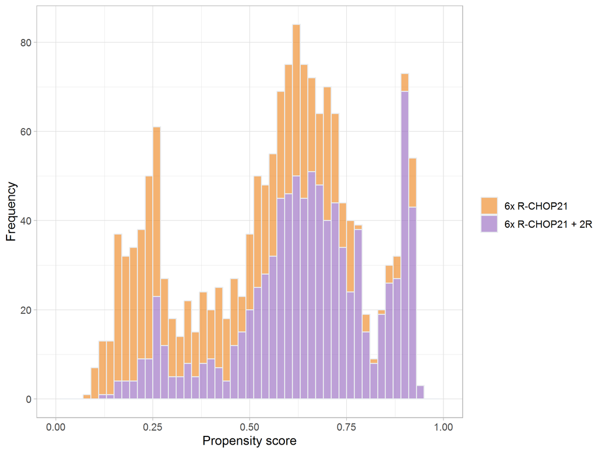

```r
# orange: #EC7F12
# purple: #9161BD
# blue: #0D88AF
overlap.assumption.plot <- ggplot2::ggplot(single.imp.DLBCL, ggplot2::aes(x=e.i, fill=as.factor(RCHOP21)))+
  ggplot2::geom_histogram(color="#e9ecef", alpha=0.6, binwidth=0.02)+
  ggplot2::theme_light()+
  ggplot2::theme(legend.title=ggplot2::element_blank(), text=ggplot2::element_text(size=12))+
  ggplot2::scale_fill_manual(values=c("#EC7F12", "#9161BD"), labels=c("6x R-CHOP21", "6x R-CHOP21 + 2R"))+
  ggplot2::ylab("Frequency")+
  ggplot2::xlab("Propensity score")+
  ggplot2::xlim(c(0, 1))
ggsave(filename=paste0(file.path, "Results/Figure S2.png"),
        plot=overlap.assumption.plot,
        width=8, height=6, dpi=300)
```

# Stabilized inverse propensity score weights

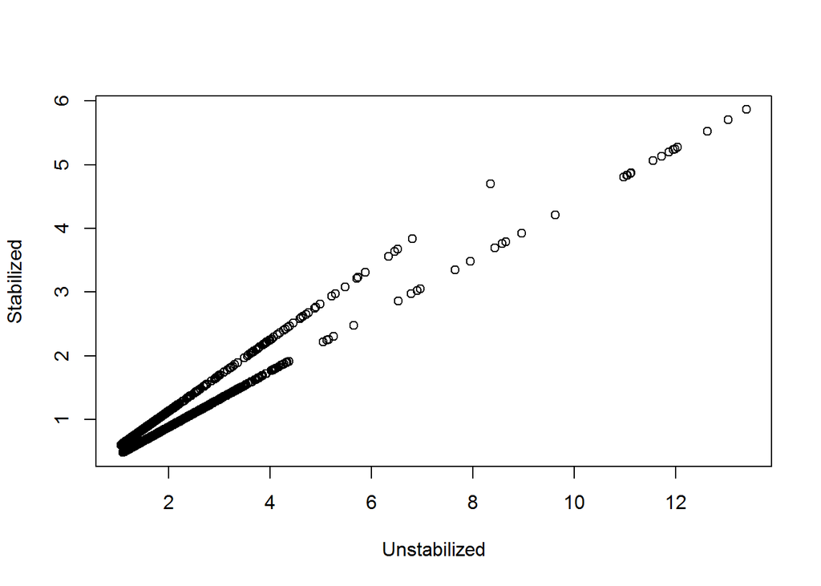

```r
P.Z <- mean(single.imp.DLBCL$RCHOP21)
single.imp.DLBCL$stabilized.w.i <- P.Z*single.imp.DLBCL$RCHOP21/single.imp.DLBCL$e.i +
                        (1-P.Z)*(1-single.imp.DLBCL$RCHOP21)/(1-single.imp.DLBCL$e.i)
plot(x=single.imp.DLBCL$RCHOP21/single.imp.DLBCL$e.i+(1-single.imp.DLBCL$RCHOP21)/(1-single.imp.DLBCL$e.i),
     y=single.imp.DLBCL$stabilized.w.i,
     xlab="Unstabilized", ylab="Stabilized")
```

##### Check balance before and after weighting using standardized mean difference

```r
# define number of quartiles
g <- 4
main.titles <- c("0-1", "2", "3", "4-5")
# covariates
vars <- c("geslacht",
          "ipi_ldh",
          "ipi_ps",
          "ipi_extra",
          "malignancy",
          "center",
          "lft",
          paste0("region", 1:9),
          paste0("stage", 2:4),
          "ses.low", "ses.medium", "ses.high")
# construct a table
tabUnmatched.imp <- c()
tabWeighted.imp <- c()
for (imp in 1:m){
  # unweighted
  tabUnmatched.imp <- cbind(tabUnmatched.imp, as.numeric(tableone::ExtractSmd(tableone::CreateTableOne(vars = vars,
                                       strata = "RCHOP21",
                                       data = mice::complete(DLBCL, imp), test=FALSE))))

  # weighted data
  weighted.data.imp <- survey::svydesign(ids = ~ 1,
                                     data = mice::complete(DLBCL, imp),
                                     weights = ~ single.imp.DLBCL$stabilized.w.i)
  # construct a table
  tabWeighted.imp <- cbind(tabWeighted.imp, as.numeric(tableone::ExtractSmd(tableone::svyCreateTableOne(vars = vars,
                                       strata = "RCHOP21",
                                       data = weighted.data.imp,
                                       test = FALSE))))

}
tabUnmatched <- rowMeans(tabUnmatched.imp)
tabWeighted <- rowMeans(tabWeighted.imp)

# show table with SMD
# print(tableone::CreateTableOne(vars = vars,
#                                strata = "RCHOP21",
#                                data = mice::complete(DLBCL, imp), test=FALSE), smd=TRUE) # 736 - 890
# 10 covariates with important imbalance
# stats::addmargins(table(tableone::ExtractSmd(tableone::CreateTableOne(vars = vars,
#                                        strata = "RCHOP21",
#                                        data = mice::complete(DLBCL, imp), test=FALSE)) > 0.1))

# show table with SMD
# print(tableone::svyCreateTableOne(vars = vars,
#                                   strata = "RCHOP21",
#                                   data = weighted.data.imp,
#                                   test = FALSE), smd = TRUE) # 747.42 - 878.17
# 0 covariates with important imbalance
# stats::addmargins(table(tableone::ExtractSmd(tableone::svyCreateTableOne(vars = vars,
#                                        strata = "RCHOP21",
#                                        data = weighted.data.imp,
#                                        test = FALSE)) > 0.1))

# love plot for propensity scores based on all patients
love.df <- data.frame(names=c("Gender",
                              "Elevated serum LDH",
                              "Performance status",
                              "Extranodal sites",
                              "Previous malignancies",
                              "Treatment at an academic center",
                              "Age",
                              paste("Region of treatment", 1:9),
                              paste("Ann Arbor stage", 2:4),
                              "Low SES", "Medium SES", "High SES"),
                      unweighted=tabUnmatched,
                      weighted=tabWeighted,
                      diff=tabUnmatched-tabWeighted)
colnames(love.df) <- c("names", "unweighted", "weighted", "difference")
ordered.love.df <- love.df[order(love.df$difference, decreasing=FALSE),]
cat("Maximum Standardized Mean Difference:", max(ordered.love.df$weighted), "\n")
```

```
## Maximum Standardized Mean Difference: 0.07087068
```

```r
# ensure right order
ordered.love.df$names <- factor(ordered.love.df$names, levels=ordered.love.df$names)
ggsave(filename=paste0(file.path, "Results/Figure S3.png"),
       plot=ggplot2::ggplot(data=ordered.love.df, ggplot2::aes(y=names, x=unweighted))+
             ggplot2::geom_point(x=ordered.love.df$unweighted, colour="#EC7F12", size=3)+
             ggplot2::geom_point(x=ordered.love.df$weighted, colour="#9161BD", size=3)+
             ggplot2::geom_vline(xintercept=0, linetype="dashed")+
             ggplot2::ggtitle("Covariate balance for all patients")+
             ggplot2::xlab("Standardized mean difference")+
             ggplot2::ylab("")+
             ggplot2::xlim(0, 1)+
             ggplot2::theme_classic()+
             ggplot2::theme(plot.title=element_text(hjust=0.5),
                            text=ggplot2::element_text(size=17)),
       width=8, height=6, dpi=300)
```

# Recurrence and overall survival

### Set time-to-event

The event-free survival indicator (efsi) is 1 if the patient has a recurrence or if there is no response to initial treatment and second line treatment is administered, and 0 otherwise. The time until the event is the event-free survival time.

```r
# omit first events
single.imp.DLBCL.EFS <- single.imp.DLBCL[-which(single.imp.DLBCL$EFS.time<0),]

# median follow-up time
single.imp.DLBCL.EFS$S.EFS <- survival::Surv(event=single.imp.DLBCL.EFS$efsi, time=single.imp.DLBCL.EFS$EFS.time)
med.EFS.time <- stats::quantile(prodlim::prodlim(prodlim::Hist(EFS.time, efsi==1)~1,
                                                 data=single.imp.DLBCL.EFS, reverse=TRUE))$quantiles.survival
paste0(sprintf("%.2f", med.EFS.time[3, "quantile"]), ", IQR: ",
       sprintf("%.2f", med.EFS.time[4, "quantile"]), "-",
       sprintf("%.2f", med.EFS.time[2, "quantile"]))
```

```
## [1] "4.44, IQR: 3.84-5.32"
```

Set the overall survival.

```r
single.imp.DLBCL.OS <- single.imp.DLBCL
single.imp.DLBCL.OS$S.OS <- survival::Surv(event=single.imp.DLBCL.OS$dood, time=single.imp.DLBCL.OS$OS.time)
med.FU.time <- stats::quantile(prodlim::prodlim(prodlim::Hist(OS.time, dood==1)~1,
                                                data=single.imp.DLBCL.OS, reverse=TRUE))$quantiles.survival
paste0(sprintf("%.2f", med.FU.time[3, "quantile"]), ", IQR: ",
       sprintf("%.2f", med.FU.time[4, "quantile"]), "-",
       sprintf("%.2f", med.FU.time[2, "quantile"]))
```

```
## [1] "4.44, IQR: 3.84-5.28"
```

```r
save(DLBCL, file=paste0(file.path, "Data/imputed.DLBCL.Rdata"), compress=TRUE)
```

### Helper functions

```r
ylabs <- data.frame(outcome=c("EFS", "OS"),
                    label=c("EFS probability", "OS probability"))
limit_year_EFS <- 5
limit_year_OS <- 5
```

### For each outcome, show:

1. Kaplan-Meier curves
2. If proportional hazard assumption is satisfied
3. Kaplan-Meier estimates, hazard ratios and RMST stratified by IPI score

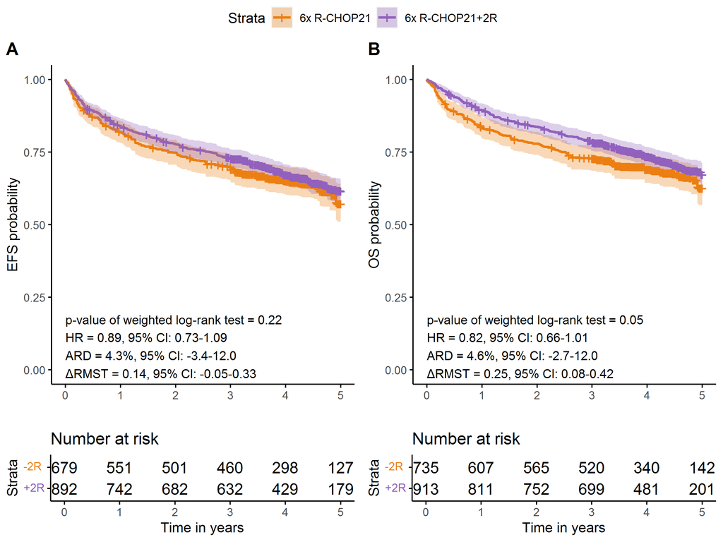

```r
for (outcome in ylabs$outcome){
  # Survival outcome
  S.temp <- eval(parse(text=paste0("single.imp.DLBCL.", outcome, "$S.", outcome)))
  limit_year <- eval(parse(text=(paste0("limit_year_", outcome))))

  # Set the censoring of patients with follow-up time more than x years to "censored"
  S.temp[S.temp[,1]>limit_year, 2] <- 0
  # Set the follow-up time to x years for patients with follow-up time more than x years.
  S.temp[S.temp[,1]>limit_year, 1] <- limit_year
  assign(paste0("S.", outcome, ".limit"), S.temp)

  # Kaplan-Meier plots
  km <- survival::survfit(eval(parse(text=paste0("S.", outcome, ".limit ~ RCHOP21"))),
                          data=eval(parse(text=paste0("single.imp.DLBCL.", outcome))),
                          weights=eval(parse(text=paste0("single.imp.DLBCL.", outcome, "[, \"stabilized.w.i\"]"))),
                          robust=TRUE, type="kaplan-meier", conf.type="log")
  assign(paste0("km_", outcome), km)

  # Kaplan-Meier estimates at x-years
  treat <- summary(km, times=limit_year)
  ARD <- diff(treat$surv)
  ARD_text <- paste0(sprintf("%.1f", ARD*100), "%")
  assign(paste0("ARD_", outcome), ARD)
  ARD_se <- sqrt(sum((treat$std.err)^2))
  ARD_CI_text <- paste0(sprintf("%.1f", (ARD-1.96*ARD_se)*100),
                   "-", sprintf("%.1f", (ARD+1.96*ARD_se)*100))
  assign(paste0("ARD_CI_", outcome), ARD_CI_text)

  # Log-rank test using stabilized weights is rejected,
  # thus the survival between the two treatment groups is significantly different
  LRT <- RISCA::ipw.log.rank(times=eval(parse(text=paste0("S.", outcome, ".limit[, 1]"))),
                             failures=eval(parse(text=paste0("S.", outcome, ".limit[, 2]"))),
                             variable=eval(parse(text=paste0("single.imp.DLBCL.", outcome, "$RCHOP21"))),
                             weights=eval(parse(text=paste0("single.imp.DLBCL.", outcome, "[, \"stabilized.w.i\"]"))))
  LRT_text <- sprintf("%.2f", LRT$p.value)

  # Univariate Cox proportional hazards model with stabilized weights
  cox <- survival::coxph(eval(parse(text=paste0("S.", outcome, ".limit ~ RCHOP21"))),
                         data=eval(parse(text=paste0("single.imp.DLBCL.", outcome))),
                         weights=eval(parse(text=paste0("single.imp.DLBCL.", outcome, "[, \"stabilized.w.i\"]"))),
                         robust=TRUE)
  HR <- exp(coef(cox))
  HR_text <- sprintf("%.2f", HR)
  HR_text_lower <- sprintf("%.2f", exp(confint(cox)[, "2.5 %"]))
  HR_text_upper <- sprintf("%.2f", exp(confint(cox)[, "97.5 %"]))

  # Restricted Mean Survival Time Analysis
  RMST <- survival:::survmean(km, rmean=limit_year)
  dRMST <- diff(RMST$matrix[, "rmean"])
  dRMST_text <- sprintf("%.2f", dRMST)
  assign(paste0("dRMST_", outcome), dRMST_text)
  dRMST_se <- RMST$matrix[, "se(rmean)"]
  dRMST_CI_text <- paste0(sprintf("%.2f", dRMST-1.96*sqrt(sum(dRMST_se^2))),
                          "-", sprintf("%.2f", dRMST+1.96*sqrt(sum(dRMST_se^2))))
  assign(paste0("dRMST_CI_", outcome), dRMST_CI_text)

  # Kaplan-Meier plot
  km_plot <- survminer::ggsurvplot(km,
                                  palette=c("#EC7F12", "#9161BD"),
                                  ggtheme = theme(
                                    axis.line = element_line(colour = "black"),
                                    panel.background = element_rect(fill='transparent'), #transparent panel bg
                                    plot.background = element_rect(fill='transparent', color=NA), #transparent plot bg
                                    panel.grid.major = element_blank(), #remove major gridlines
                                    panel.grid.minor = element_blank(), #remove minor gridlines
                                    legend.background = element_rect(fill='transparent'), #transparent legend bg
                                    legend.box.background = element_rect(color = NA, fill='transparent') #transparent legend panel
                                  ),
                                  legend.labs=c("6x R-CHOP21", "6x R-CHOP21+2R"),
                                  xlab="",
                                  ylab=ylabs[ylabs$outcome==outcome, "label"],
                                  risk.table=FALSE, conf.int="True",
                                  robust=TRUE, pval=FALSE)$plot+
                ggplot2::annotate("text", x=0, y=0.05,
                                  label=paste0("p-value of weighted log-rank test = ",
                                               LRT_text, "\n",
                                               "HR = ", HR_text,
                                               paste0(", 95% CI: ",
                                                      HR_text_lower, "-",
                                                      HR_text_upper, "\n"),
                                               "ARD = ", ARD_text,
                                               paste0(", 95% CI: ", ARD_CI_text), "\n",
                                               "\u0394RMST = ", dRMST_text,
                                               paste0(", 95% CI: ", dRMST_CI_text), "\n"),
                                  size=3.5, hjust=0)
  assign(paste0("km_plot_", outcome), km_plot)
  km_table <- survminer::ggsurvplot(km,
                                    palette=c("#EC7F12", "#9161BD"),
                                    ggtheme = theme(
                                       axis.line = element_line(colour = "black"),
                                       panel.background = element_rect(fill='transparent'), #transparent panel bg
                                       plot.background = element_rect(fill='transparent', color=NA), #transparent plot bg
                                       panel.grid.major = element_blank(), #remove major gridlines
                                       panel.grid.minor = element_blank(), #remove minor gridlines
                                       legend.background = element_rect(fill='transparent'), #transparent legend bg
                                       legend.box.background = element_rect(fill='transparent') #transparent legend panel
                                    ),
                                    legend.labs=c("-2R", "+2R"),
                                    xlab="Time in years",
                                    risk.table=TRUE,
                                    robust=TRUE,
                                    pval=FALSE)$table
  assign(paste0("km_table_", outcome), km_table)

  # Write results to Excel
  openxlsx::write.xlsx(x=data.frame(names=c("6x R-CHOP21", "6x R-CHOP21+2R", "Difference", "P-value"),
           KMest=c(sprintf("%.1f", treat$surv*100),
                   sprintf("%.1f", ARD*100),
                   LRT_text),
           KMCI=c(paste0(sprintf("%.1f", treat$lower*100),
                         "-", sprintf("%.1f", treat$upper*100)),
                  ARD_CI_text,
                  ""),
           Coxest=c("(ref)",
                    HR_text,
                    "",
                    as.numeric(sprintf("%.2f", summary(cox)$robscore["pvalue"]))),
           CoxCI=c("",
                   paste0(HR_text_lower, "-",
                          HR_text_upper),
                   "",
                   ""),
           RMSTest=c("",
                     "",
                     dRMST_text,
                     ""),
           RMSTCI=c("",
                    "",
                    dRMST_CI_text,
                    "")),
           file=paste0(file.path, "Results/overall.", outcome , ".xlsx"),
           sheetName=outcome)
}

# PH assumption plot
png(file=paste0(file.path, "Results/Plots/PH.assumption.png"),
    width=600, height=300)
par(mfrow=c(1, 2))
outcome <- "EFS"
plot(survival::cox.zph(survival::coxph(eval(parse(text=paste0("S.", outcome, ".limit ~ RCHOP21"))),
                         data=eval(parse(text=paste0("single.imp.DLBCL.", outcome))),
                         weights=eval(parse(text=paste0("single.imp.DLBCL.", outcome, "[, \"stabilized.w.i\"]"))),
                         robust=TRUE)), main="a. Event-free survival")
outcome <- "OS"
plot(survival::cox.zph(survival::coxph(eval(parse(text=paste0("S.", outcome, ".limit ~ RCHOP21"))),
                         data=eval(parse(text=paste0("single.imp.DLBCL.", outcome))),
                         weights=eval(parse(text=paste0("single.imp.DLBCL.", outcome, "[, \"stabilized.w.i\"]"))),
                         robust=TRUE)), main="b. Overall survival")
grDevices::dev.off()
```

# Subgroup analysis stratified by IPI score

```r
# obtain average IPI score across multiple imputations
comb.ipi.imp.EFS <- c()
comb.ipi.imp.OS <- c()
for (imp in 1:m){
  comb.ipi.imp.EFS <- cbind(comb.ipi.imp.EFS, mice::complete(DLBCL, imp)[-which(single.imp.DLBCL$EFS.time<0), "ipi_score"])
  comb.ipi.imp.OS <- cbind(comb.ipi.imp.OS, mice::complete(DLBCL, imp)[, "ipi_score"])
}
combined.IPI.EFS <- round(rowMeans(comb.ipi.imp.EFS), 0)
combined.IPI.OS <- round(rowMeans(comb.ipi.imp.OS), 0)

for (outcome in ylabs$outcome){
  # estimate treatment effect in each quartile
  limit_year <- eval(parse(text=(paste0("limit_year_", outcome))))
  KM_est_quartile <- c()
  plot_KM <- list()
  table_KM <- list()
  HR_quartile <- c()
  HR_quartile_lower <- c()
  HR_quartile_upper <- c()
  dRMST_quartiles <- c()
  dRMST_quartiles_lower <- c()
  dRMST_quartiles_upper <- c()
  LRT_stat_quartile <- c()
  LRT_p_quartile <- c()
  for (ipi.i in 1:g){
    # select data for only ith quartile
    quartile.DLBCL <- eval(parse(text=paste0("single.imp.DLBCL.", outcome, "[combined.IPI.", outcome, "==ipi.i,]")))

    # Survival outcome
    S.quartile <- eval(parse(text=paste0("quartile.DLBCL$S.", outcome)))
    # Set the censoring of patients with follow-up time more than x years to "censored"
    S.quartile[S.quartile[,1]>limit_year, 2] <- 0
    # Set the follow-up time to x years for patients with follow-up time more than x years.
    S.quartile[S.quartile[,1]>limit_year, 1] <- limit_year
    quartile.DLBCL$S.quartile <- S.quartile

    # event-free survival at 5 years
    km_quartile <- survival::survfit(S.quartile~RCHOP21,
                                     data=quartile.DLBCL, robust=TRUE,
                                     weights=quartile.DLBCL[, "stabilized.w.i"],
                                     type="kaplan-meier", conf.type="log")
    # save survival
    treat_quartile <- summary(km_quartile, times = limit_year)
    KM_est_quartile <- rbind(KM_est_quartile,
                             cbind(treat_quartile$surv, treat_quartile$std.err,
                                   treat_quartile$lower, treat_quartile$upper))

    # log-rank test
    LRT_quartile <- RISCA::ipw.log.rank(times=S.quartile[, 1], failures=S.quartile[, 2],
                      variable=quartile.DLBCL$RCHOP21,
                      weights=quartile.DLBCL[, "stabilized.w.i"])
    LRT_stat_quartile <- c(LRT_stat_quartile, LRT_quartile$statistic)
    LRT_p_quartile <- c(LRT_p_quartile, LRT_quartile$p.value)

    # univariate cox
    cox_quartile <- survival::coxph(S.quartile~RCHOP21, data=quartile.DLBCL,
                                  weights=quartile.DLBCL[, "stabilized.w.i"],
                                  robust=TRUE)
    PH.assumption <- survival::cox.zph(cox_quartile)$table["RCHOP21", "p"]

    # save hazard ratios
    HR_quartile <- c(HR_quartile, as.numeric(exp(coef(cox_quartile)[1])))
    HR_quartile_lower <- c(HR_quartile_lower, as.numeric(exp(confint(cox_quartile)[1,1])))
    HR_quartile_upper <- c(HR_quartile_upper, as.numeric(exp(confint(cox_quartile)[1,2])))

    # RMST
    RMST_quartile <- survival:::survmean(km_quartile, rmean=limit_year)
    dRMST_Q <- diff(RMST_quartile$matrix[, "rmean"])
    dRMST_quartiles <- c(dRMST_quartiles, dRMST_Q)
    RMST_text_quartile <- sprintf("%.1f", dRMST_Q)

    dRMST_Q_se <- RMST_quartile$matrix[, "se(rmean)"]
    dRMST_quartiles_lower <- c(dRMST_quartiles_lower, dRMST_Q-1.96*sqrt(sum(dRMST_Q_se^2)))
    dRMST_quartiles_upper <- c(dRMST_quartiles_upper, dRMST_Q+1.96*sqrt(sum(dRMST_Q_se^2)))

    # make text for KM plots
    LRT_text_quartile <- sprintf("%.1f", LRT_quartile$p.value)
    HR_text_quartile <- sprintf("%.1f", exp(coef(cox_quartile)[1]))
    HR_text_quartile_lower <- sprintf("%.1f", exp(confint(cox_quartile)[1,1]))
    HR_text_quartile_upper <- sprintf("%.1f", exp(confint(cox_quartile)[1,2]))

    # save Kaplan-Meier plots
    plot_KM[[ipi.i]] <- survminer::ggsurvplot(km_quartile,
                                              conf.int="True",
                                              palette=c("#EC7F12", "#9161BD"),
                                              ggtheme = ggplot2::theme(
                                                 axis.line = ggplot2::element_line(colour = "black"),
                                                 panel.background = ggplot2::element_rect(fill='transparent'), #transparent panel bg
                                                 plot.background = ggplot2::element_rect(fill='transparent', color=NA), #transparent plot bg
                                                 panel.grid.major = ggplot2::element_blank(), #remove major gridlines
                                                 panel.grid.minor = ggplot2::element_blank(), #remove minor gridlines
                                                 legend.background = ggplot2::element_rect(fill='transparent'), #transparent legend bg
                                                 legend.box.background = ggplot2::element_rect(km_plot, fill='transparent') #transparent legend panel
                                              ),
                                              ylim=c(0, 1), risk.table=TRUE)$plot+
    ggplot2::theme(legend.position = "none")+
    ggplot2::ylab(ylabs[ylabs$outcome==outcome, "label"])+
    ggplot2::xlab("")+
    ggplot2::theme(plot.title=ggplot2::element_text(hjust=0.5, size=10),
           axis.text.x=ggplot2::element_text(size=10),
           axis.title.x=ggplot2::element_text(size=10),
           axis.text.y=ggplot2::element_text(size=10),
           axis.title.y=ggplot2::element_text(size=10))+
    ggplot2::ggtitle(paste0("(N=", nrow(quartile.DLBCL), ")"))

    # save Kaplan-Meier risk table
    table_KM[[ipi.i]] <- survminer::ggsurvplot(km_quartile,
      palette=c("#EC7F12", "#9161BD"),
      ggtheme = theme(axis.line = element_line(colour = "black"),
                      axis.text.y = ggplot2::element_text(size=10),
                      axis.title.y = ggplot2::element_text(size=10),
                      axis.line.y = ggplot2::element_blank(),
                      axis.ticks.y = ggplot2::element_blank(),
                      axis.line.x = ggplot2::element_blank(),
                      axis.ticks.x = ggplot2::element_blank(),
                      axis.text.x = ggplot2::element_blank(),
                      axis.title.x = ggplot2::element_blank(),
                      panel.background = ggplot2::element_rect(fill='transparent'), #transparent panel bg
                      plot.background = ggplot2::element_rect(fill='transparent', color=NA), #transparent plot bg
                      panel.grid.major = ggplot2::element_blank(), #remove major gridlines
                      panel.grid.minor = ggplot2::element_blank(), #remove minor gridlines
                      legend.background = ggplot2::element_rect(fill='transparent'), #transparent legend bg
                      legend.box.background = ggplot2::element_rect(fill='transparent') #transparent legend panel
      ),
      legend.labs=c("-2R", "+2R"),
      xlab="Time in years",
      risk.table=TRUE,
      risk.table.title=element_blank(),
      risk.table.fontsize=3,
      robust=TRUE, pval=FALSE)$table
  }
```

```r
  # combine Kaplan-Meier estimates into one data frame
  KM_est_quartile <- cbind(KM_est_quartile, rep(c(0, 1), g))
  KM_est_quartile <- cbind(KM_est_quartile, rep(1:g, each=2))
  colnames(KM_est_quartile) <- c("estimate", "sd", "lower", "upper", "treatment", "risk.group")
  KM_est_quartile <- as.data.frame(KM_est_quartile)
  assign(paste0("KM_est_quartile_", outcome), KM_est_quartile)

  # combine hazard ratios into one data frame
  HR_df_quartile <- data.frame(risk.group=1:g, estimate=HR_quartile,
                               lower=HR_quartile_lower, upper=HR_quartile_upper)

  # combine RMST into one data frame
  dRMST_df_quartile <- data.frame(risk.group=1:g, estimate=dRMST_quartiles,
                                 lower=dRMST_quartiles_lower, upper=dRMST_quartiles_upper)
  assign(paste0("dRMST_df_quartile_", outcome), dRMST_df_quartile)

  # Calculate the absolute difference in event-free survival, i.e. benefit and harm.
  diff <- c()
  j <- 1
  for (i in seq(from=1, to=nrow(KM_est_quartile), by=2)){
    diff <- rbind(diff, KM_est_quartile[i+1,]-KM_est_quartile[i,])

    # standard deviation of difference is square root of sum of variances
    diff[j, "sd"] <- sqrt(KM_est_quartile[i+1, "sd"]^2+KM_est_quartile[i, "sd"]^2)
    diff[j, "lower"] <- diff[j, "estimate"]-1.96*diff[j, "sd"]
    diff[j, "upper"] <- diff[j, "estimate"]+1.96*diff[j, "sd"]
    j <- j + 1
  }
  diff <- as.data.frame(diff)
  diff$risk.group <- 1:g
  ARD_df_quartile <- data.frame(risk.group=1:g, estimate=diff$estimate*100,
                                lower=diff$lower*100, upper=diff$upper*100)
  assign(paste0("ARD_df_quartile_", outcome), ARD_df_quartile)

  # Write results to Excel
  results.df.q <- data.frame(cbind(c(rep("ARD", 4), rep("HR", 4), rep("RMST", 4)),
                              rbind(ARD_df_quartile,
                                    HR_df_quartile,
                                    dRMST_df_quartile)))
  results.df.q$text <- paste0(sprintf("%.2f", results.df.q$estimate), ", 95% CI:",
                              sprintf("%.2f", results.df.q$lower), "; ",
                              sprintf("%.2f", results.df.q$upper))
  openxlsx::write.xlsx(results.df.q,
           file=paste0(file.path, "Results/IPI.stratified.", outcome, ".xlsx"),
           sheetName=outcome)

  # Kaplan-Meier plots
  KM_plots <- ggpubr::ggarrange(plot_KM[[1]]+ggplot2::labs(tag="A"),
                                plot_KM[[2]]+ggpubr::rremove("y.axis")+
                                  ggpubr::rremove("ylab")+
                                  ggpubr::rremove("y.text")+
                                  ggpubr::rremove("y.ticks"),
                                plot_KM[[3]]+ggpubr::rremove("y.axis")+
                                  ggpubr::rremove("ylab")+
                                  ggpubr::rremove("y.text")+
                                  ggpubr::rremove("y.ticks"),
                                plot_KM[[4]]+ggpubr::rremove("y.axis")+
                                  ggpubr::rremove("ylab")+
                                  ggpubr::rremove("y.text")+
                                  ggpubr::rremove("y.ticks"),
                                ncol=4, nrow=1,
                                widths=c(1, 0.8, 0.8, 0.8),
                                align="h")

  # Kaplan-Meier tables
  table_KM_plots <- ggpubr::ggarrange(table_KM[[1]],
                                table_KM[[2]]+ggpubr::rremove("y.axis")+
                                  ggpubr::rremove("ylab")+
                                  ggpubr::rremove("y.text")+
                                  ggpubr::rremove("y.ticks"),
                                table_KM[[3]]+ggpubr::rremove("y.axis")+
                                  ggpubr::rremove("ylab")+
                                  ggpubr::rremove("y.text")+
                                  ggpubr::rremove("y.ticks"),
                                table_KM[[4]]+ggpubr::rremove("y.axis")+
                                  ggpubr::rremove("ylab")+
                                  ggpubr::rremove("y.text")+
                                  ggpubr::rremove("y.ticks"),
                                ncol=4, nrow=1,
                                widths=c(1, 0.8, 0.8, 0.8),
                                align="h")

  # plot for absolute reduction in survival
  avg.diff <- diff(summary(eval(parse(text=paste0("km_", outcome))),
                           times = limit_year)$surv)
  diff.plot <- ggplot2::ggplot(data=diff,
                               ggplot2::aes(x=factor(risk.group), y=estimate))+
    ggplot2::geom_hline(yintercept=0)+
    ggplot2::geom_hline(yintercept=avg.diff, linetype="dashed", linewidth=1.2)+
    ggplot2::geom_errorbar(ggplot2::aes(ymin=lower, ymax=upper),
                           position=ggplot2::position_dodge(0.9), width=0)+
    ggplot2::geom_point(size=5, shape=18, color="#EC7F12")+
    ggplot2::scale_y_continuous(limits=c(min(diff$lower, 0),
                                         max(diff$upper)),
                                labels=scales::percent_format(accuracy=1))+
    ggplot2::theme(text=ggplot2::element_text(size=12),
                   axis.line.y = element_line(colour = "black"),
                   panel.background = element_rect(fill='transparent'), #transparent panel bg
                   plot.background = element_rect(fill='transparent', color=NA), #transparent plot bg
                   panel.grid.major = ggplot2::element_blank(),
                   panel.grid.minor = ggplot2::element_blank())+
    ggplot2::ylab("ARD") +
    ggplot2::theme(axis.title.x=ggplot2::element_blank(),
                   axis.text.x=ggplot2::element_blank(),
                   axis.ticks.x=ggplot2::element_blank())+
    ggplot2::labs(tag="C")

  # test for multiplicative HTE
  DLBCL.temp <- eval(parse(text=paste0("single.imp.DLBCL.", outcome)))
  S.temp <- eval(parse(text=paste0("S.", outcome, ".limit")))
  ipi.temp <- eval(parse(text=paste0("combined.IPI.", outcome)))
  test.HR <- summary(coxph(S.temp ~ RCHOP21*ipi.temp, data=DLBCL.temp))$coefficients[3, "Pr(>|z|)"]
```

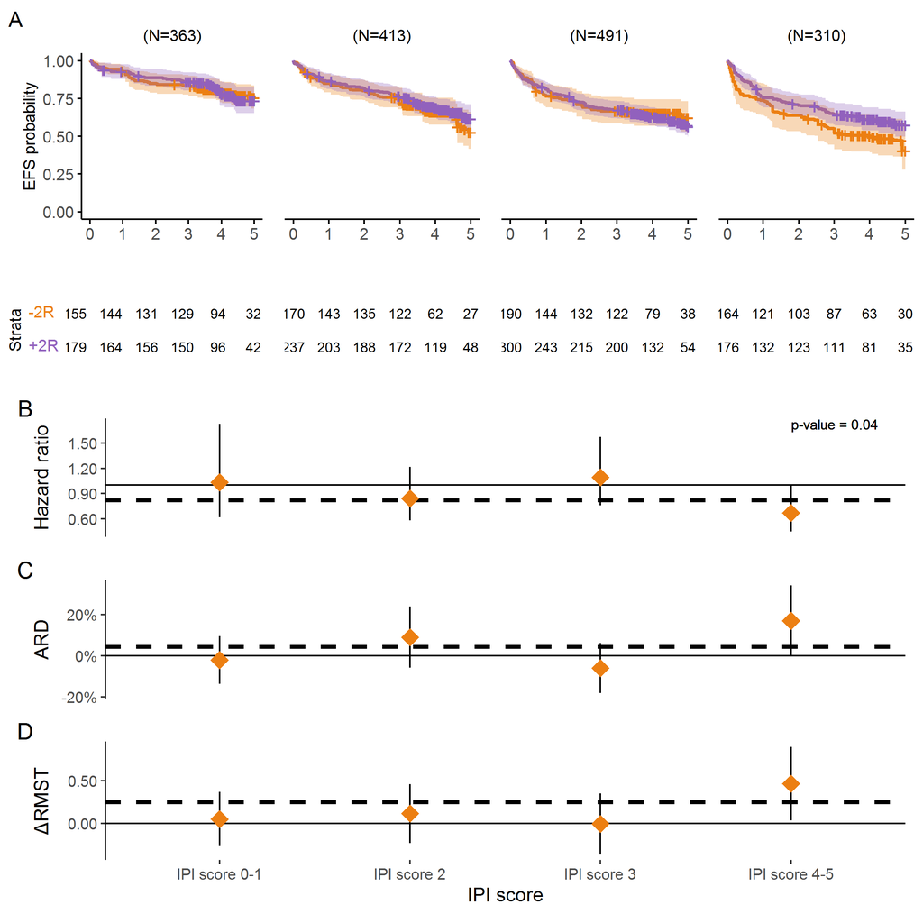

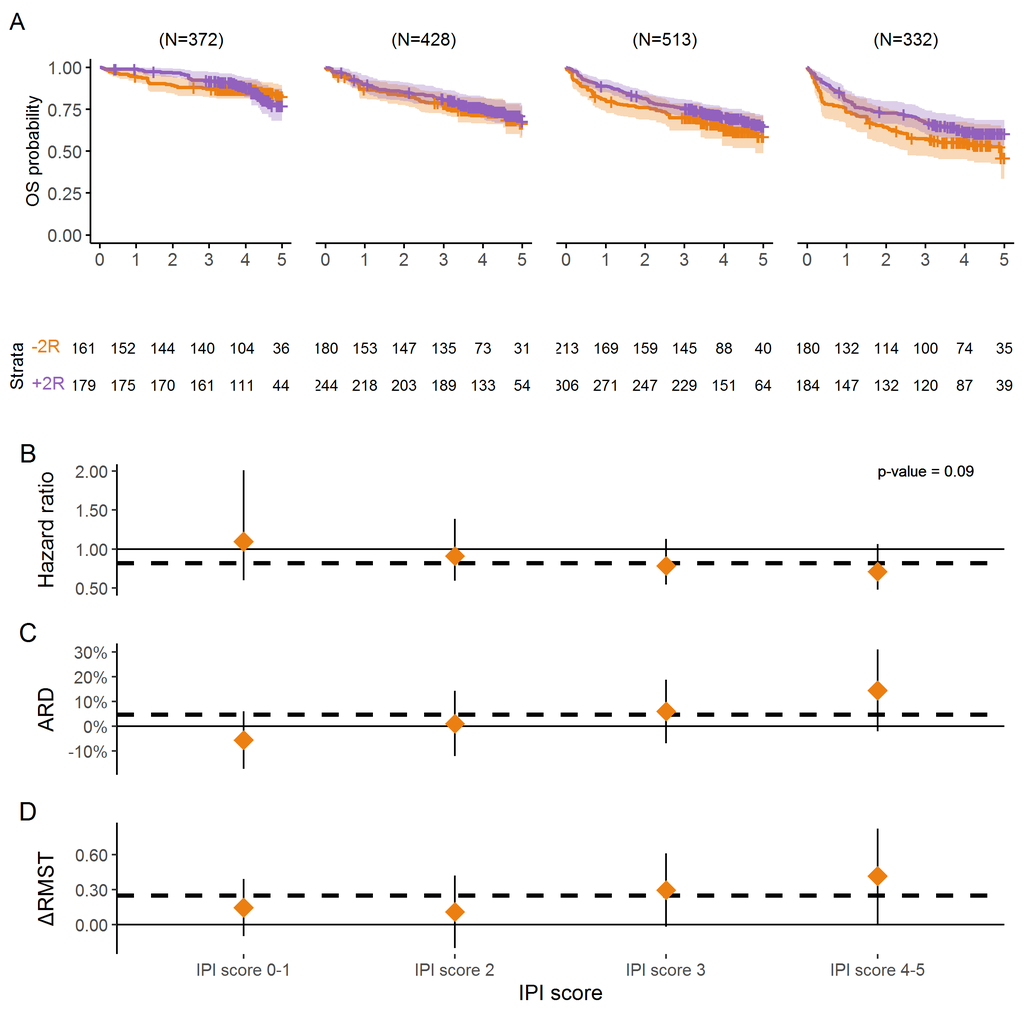

```r
  # create plot for hazard ratios
  hazard.plot <- ggplot2::ggplot(data=HR_df_quartile, ggplot2::aes(x=risk.group, y=estimate))+
    ggplot2::geom_hline(yintercept=1)+
    ggplot2::geom_hline(yintercept=HR, linetype="dashed", linewidth=1.2)+
    ggplot2::geom_errorbar(ggplot2::aes(ymin=lower, ymax=upper),
                           position=ggplot2::position_dodge(0.9), width=0)+
    ggplot2::geom_point(size=5, shape=18, color="#EC7F12")+
    ggplot2::scale_x_discrete(limits=as.factor(1:g))+
    ggplot2::scale_y_continuous(limits=c(min(HR_df_quartile$lower),
                                         max(HR_df_quartile$upper, 1)),
                                labels=scales::number_format(accuracy=0.01))+
    ggplot2::theme(text=ggplot2::element_text(size=12),
                    axis.title.x=ggplot2::element_blank(),
                    axis.text.x=ggplot2::element_blank(),
                    axis.ticks.x=ggplot2::element_blank(),
                    axis.line.y = element_line(colour = "black"),
                    panel.background = element_rect(fill='transparent'), #transparent panel bg
                    plot.background = element_rect(fill='transparent', color=NA), #transparent plot bg
                    panel.grid.major = ggplot2::element_blank(),
                    panel.grid.minor = ggplot2::element_blank())+
    ggplot2::ylab("Hazard ratio")+
    ggplot2::geom_text(mapping=aes(x=g, y=max(HR_df_quartile$upper),
                                   label=paste0("p-value = ", sprintf("%.2f", test.HR))),
                       hjust=0, size=3)+
    ggplot2::labs(tag="B")

  # create plot for RMST
  RMST.plot <- ggplot2::ggplot(data=dRMST_df_quartile, ggplot2::aes(x=risk.group, y=estimate))+
    ggplot2::geom_hline(yintercept=0)+
    ggplot2::geom_hline(yintercept=dRMST, linetype="dashed", linewidth=1.2)+
    ggplot2::geom_errorbar(ggplot2::aes(ymin=lower, ymax=upper),
                           position=ggplot2::position_dodge(0.9), width=0)+
    ggplot2::geom_point(size=5, shape=18, color="#EC7F12")+
    ggplot2::scale_x_discrete(limits=c("1"="IPI score 0-1", "2"="IPI score 2", "3"="IPI score 3", "4"="IPI score 4-5"))+
    ggplot2::scale_y_continuous(limits=c(min(dRMST_df_quartile$lower, 0),
                                         max(dRMST_df_quartile$upper)),
                                labels=scales::number_format(accuracy=0.01))+
    ggplot2::theme(text=ggplot2::element_text(size=12),
                    axis.line.y = element_line(colour = "black"),
                    panel.background = element_rect(fill='transparent'), #transparent panel bg
                    plot.background = element_rect(fill='transparent', color=NA), #transparent plot bg
                    panel.grid.major = ggplot2::element_blank(),
                    panel.grid.minor = ggplot2::element_blank())+
    ggplot2::xlab("IPI score")+
    ggplot2::ylab("\u0394RMST")+
    ggplot2::labs(tag="D")

  # save plot
  ggsave(filename=paste0(file.path, "Results/Figure IPI-stratified ", outcome, ".png"),
       plot=ggpubr::ggarrange(KM_plots, table_KM_plots,
                              hazard.plot / diff.plot / RMST.plot,
                              nrow=3, ncol=1, heights=c(5, 2, 10)),
       width=8, height=8, dpi=300)
}
```